# Topic One: Overview and What is Machine Learning

MSDA7003 - Machine Learning

KT Wong

Faculty of Social Sciences, HKU

2024-09-06

The materials in this topic are drawn from Lantz (2023) and James et al. (2023)

## Roadmap

1. What is Machine Learning
2. Some Discussion of Learning
3. Key Steps in applications of machine learning algorithms
4. Types of machine learning algorithms
5. The purpose of this course
6. Some preview of regression and classification as supervised learning

## What is machine learning

- A field of study on the development of *computer algorithms* for *transforming data* into *intelligent action*
  - goal: *teaching computers how to use data to solve a problem*
- it comes from an environment rapidly and simultaneously evolved in three areas:
  - the available data
  - `statistical` methods, and
  - computing power

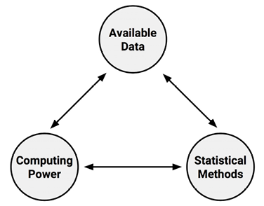

Source: Bredt, 2023

## Rough Comparisons

Comparison of Traditional Statistics, Machine Learning, and AI

|  | Traditional Statistics | Machine Learning | AI |
| --- | --- | --- | --- |
| Application | Hypothesis Testing Insight | Prediction Knowledge generation | Automation |
| Success Criterion | Greater Understanding | Ability to intervene before things happen | Efficiency Cost Savings |
| Success Metric | Statistical Significance | Trustworthiness of predictions | Return on Investment |
| Input Data Size | Small Data | Medium Data | Bigger Data |
| Implementation | Reports and Presentations for knowledge sharing | Scoring databases or Interventions in business practices | Custom Applications Automated processes |

Source: Lantz (2023)

## Human matters

- Machines are limited in their ability to thoroughly *understand* a problem
  - or understand *how the work is going to be applied toward a real-world goal*
- Learning algorithms are pure *intellectual horsepower without direction*
  - A computer may be more capable than a human of finding subtle patterns in large databases
  - it still needs a human to *motivate the analysis* and *turn the result into meaningful action*
  - In most cases, the human will determine *whether the machine’s output is valuable* and will help the machine avoid creating a limitless supply of nonsense resutls
- Machines are not good at asking questions or even knowing what questions to ask
  - They are much better at answering them, provided the question is stated in a way that the computer can comprehend

## Where Machine Learning is most useful

- augments the specialized knowledge of a subject-matter expert
- Some examples:
  - Everyday life
    - Identification of unwanted spam messages in email
    - Development of algorithms for auto-piloting drones and self-driving cars
    - Discovery of genetic sequences useful for precision medicine
  - Social science (including economics)
    - Prediction of and influence over election outcomes
    - Projection of areas where criminal activity is most likely
    - Segmentation of customer behavior for targeted advertising
    - Reduction of fraudulent credit card transactions
  - Climate change
    - Forecasts of weather behavior and long-term climate changes
    - Actuarial estimates of financial damage from storms and natural disasters
    - Optimization of energy use in homes and office buildings

# A brief discussion of learning processes

## The basic learning process

Four interrelated components:

1. `Data storage` utilizes observation, memory, and recall to provide a factual basis for further reasoning
2. `Abstraction` involves the translation of stored data into broader representations and concepts
3. `Generalization` uses abstracted data to create knowledge and inferences that drive action in new contexts
4. `Evaluation` provides a feedback mechanism to measure the utility of learned knowledge and inform potential improvements

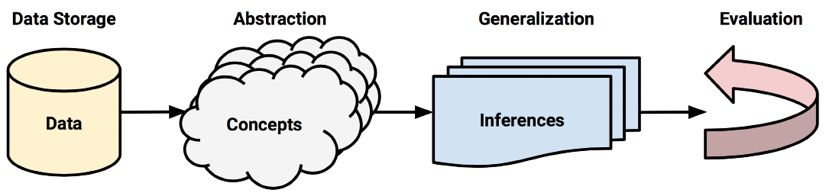

Source: Bredt, 2023

## Data Storage

- Stored data is merely ones and zeros on a computer (RAM, HDD)
- It is a collection of memories, meaningless without a broader context
- Without a higher level of understanding, knowledge is purely recall, limited to what has been seen before and nothing else

## Abstraction

- it is a process to assign a broader meaning to stored data, representing a wider, more abstract concept or idea
- Knowledge representation
  - the formation of logical structures that assist with turning raw sensory information into meaningful insight
- To retify the process of knowledge representation within *an algorithm*, the computer summarizes stored raw data using a **model**, an explicit description of the patterns within the data
  - many different types of models
    - mathematical equations
    - relational diagrams
    - logical if/else rules
    - grouping of data, like clusters
    - so on…

## Abstraction

- we need to choose the appropriate model type ourselves
- **Training**
  - fitting a model to a dataset
    - the data are transformed into an abstract form that summarize the original information
  - When training the `learner` using a given dataset, each `learner` finds its own way to model the data and identify the patterns that will be useful for the given task
  - a learned model does not itself provide new data, yet it does result in *new knowledge*
    - by imposing an assumed structure on the underlying data gives insight into the unseen
    - tt supposes a new concept that describes a way in which existing data elements may be related
  - for example, a bank might discover a seemingly innocuous type of transaction that systematically appears prior to fraudulent activity
- a psychologist might identify a combination of personality characteristics indicating a new disorder

## Generalization

- use the abstracted knowledge for future action
- the process of turning abstracted knowledge into a form that can be utilized for future action on tasks that are similar, *but not identical*, to those the learner has seen before
- It acts as a search through the entire set of models (that is, the theories or inferences) that could be established from the data during training
- the learner is tasked with limiting the patterns it discovers to only those that will be *most relevant to its future tasks*
- machine learning algorithms generally employ shortcuts that reduce the search space more quickly
  - To this end, the algorithm will employ heuristics, which are educated guesses about where to find the most useful inferences
  - Heuristics are routinely used by human beings to quickly generalize experience to new scenarios
- heuristics employed by machine learning algorithms sometimes result in erroneous conclusions
  - The algorithm is said to have a *bias* if *the conclusions are systematically erroneous*
- bias is what blinds us from some information
  - while allowing us to utilize other information for action

## Evaluation

- In order to drive action in the face of countlessess possibility, all learning must have some bias
- each learning strategy has weaknesses
  - there is no single learning algorithm to rule them all
  - the final step in the learning process is to evaluate its success and to measure the learner’s performance, despite its biases
  - The information gained in the evaluation phase can then be used to inform additional training if needed
- evaluation occurs after a model has been trained on an initial training dataset
  - the model is evaluated on *a separate test dataset* to judge how well its characterization of the training data generalizes to *new, unseen cases*

## Evaluation

- In part, models fail to generalize perfectly due to the problem of noise, which is caused by seemingly random events
  - Measurement error due to imprecise sensors that sometimes add or subtract a small amount from the readings
  - Issues with human subjects, such as survey respondents reporting random answers to questions in order to finish more quickly
  - Data quality problems, including missing, null, truncated, incorrectly coded, or corrupted values
  - Phenomena that are so complex or so little understood that they impact the data in ways that appear to be random
- Modeling noise is the basis of a problem called **overfitting**
  - most noisy data is unexplainable `by definition`
  - attempts to explain the noise will result in models that miss the true pattern the learner is trying to identify
  - those complex models do not generalize well to new cases

## Key Steps in applications of machine learning algorithms

1. Data Collection
2. Data Exploration and preparation
3. Model training
4. Model evaluation
5. Model improvement

## Types of input data

- unit of observation
  - the smallest entity with measured properties of interest for study
  - e.g. persons, objects or things, transactions, time points, geographic regions, or measurements
  - Sometimes, units of observation are combined to form units, such as person-years
- unstructured data: text, pictures, or sound
- structured data: each observation has exactly the same set of features, and these features are organized in a form that a computer may understand
  - unstructured dataset usually requires a transformation of the input data to a structured form
- data often need to be transformed into a structured matrix format before applying to machine learning algorithms

## Types of machine learning algorithms

- **Supervised learning**
  - the `target values` provide a way for the learner to know how well it has learned the desired task
  - given a set of data, a supervised learning algorithm attempts to optimize a function (the model) to find the best combination of feature values, resulting in a target output across all rows in the training data
  - aims at prediction
    - classification problems
    - Regression numerical prediction problems
- **Unsupervised learning**
  - the target values are not available
  - no single feature is of particular interest
  - a descriptive model is used for tasks that would benefit from the insight gained from summarizing data in new and interesting ways
    - pattern discovery: identify useful associations within data
    - clustering: divide a dataset into homogeneous groups
    - dimensionality reduction: reduce the number of features in a dataset
    - anomaly detection: identify unusual data points

## Types of machine learning algorithms

- [**reinforcement learning**])https://youtu.be/dV80NAlEins?t=46m05s)
  - involves a simulation in which the learner is rewarded for success or punished for failure and, over many iterations, seeks the highest cumulative reward
  - The algorithm improves at the desired learning task via the evolutionary pressure of rewards and punishment, applied to the simulated “offspring” of the learner that accumulates more beneficial random adaptations and jettisons the least helpful mutations over successive generations
  - reinforcement learning can identify novel and unforeseen solutions to the task
    - reinforcement learners trained to play video games have discovered cheats or shortcuts to complete games like Sonic the Hedgehog much faster than humans
  - computationally expensive and is vastly different from the traditional learning methods described previously
  - It is generally applied to real-world cases in which the learner can perform the task quickly and repeatedly to determine its success
  - useful for stereotypical artificial intelligence applications like self-driving vehicles and other forms of automation
  - where success or failure is easily measurable, immediate, and can be simulated in a controlled environment

## Types of machine learning algorithms

- **adversarial learning**
  - involves learning about a model’s weaknesses to strengthen its future performance or
  - harden it against malicious attacks
  - This may involve putting algorithms against one another
  - e.g. in building a reinforcement learning algorithm
    - produce fake photographs that can fool facial detection algorithms or
    - identify transaction patterns that can bypass fraud detection
- **Meta-learners**
  - focused on learning how to learn more effectively
  - Meta-learning can be beneficial for very challenging problems or when a predictive algorithm’s performance needs to be as accurate as possible
  - meta-learning algorithms use the result of past learning to inform additional learning
    - this encompasses algorithms that learn to work together in teams called **ensembles**

## Types of machine learning algorithms

- **self-supervised learning**
  - requires no manually labeled data whatsoever
  - it uses a two-step approach
    - a sophisticated model first attempts to identify meaningful groupings among records
    - the second model attempts to identify the key distinctions between the groups
  - This is a relatively recent innovation and is used primarily on *large, unstructured data sources* like audio, text, and image data
- **semi-supervised learning**
  - uses a small amount of labeled data in conjunction with an unsupervised learning analysis to help categorize the unlabeled records, which can then be used directly in a supervised learning model

## The purpose of this course

- understand the basic machine learning algorithms that are employed to teach computers to perform these tasks
- no matter the context, the fundamental machine learning process is the same (or very similar)
  - In every task, an algorithm takes data and identifies patterns that form the basis for further action
- We will focus on the supervised learning algorithms that are most commonly used in practice
- We will discuss the unsupervised learning algorithms that are used to identify patterns in data
- we will discuss various evaluation techniques that can be used to measure the success of a model
- we will discuss the process of model selection, which involves choosing the best model for a given task
- we will discuss some aspects of feature engineering
  - mainly transforming the input data into a form that is useful for the learning algorithm
  - feature engineering is a critical step in the machine learning process
  - feature selection, feature extraction, and feature construction
  - feature engineering is often the most time-consuming part of the machine learning process

## Some preview of regression and classification as supervised learning

- The Advertising data set consists of the sales of that product in 200 different markets
  - along with advertising budgets for the product in each of those markets for three different media:
    - TV, radio, and newspaper

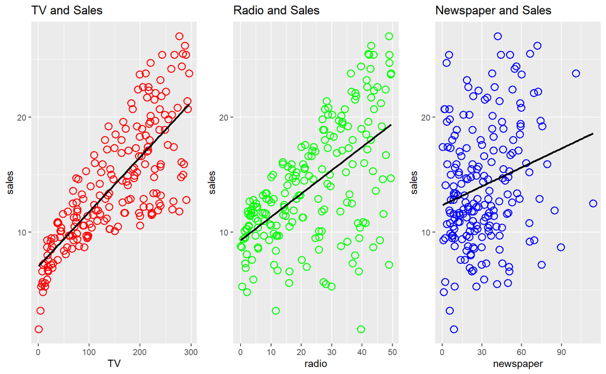

## Some preview of regression and classification as supervised learning

- Build a model to predict the sales of a product based on the advertising budget for the three media

$$\textrm{Sales} \approx f(\textrm{TV, Radio, Newspaper})$$

- `Sales` is called a response, dependent, or target variable, labelled as $Y$
- `TV`, `Radio`, and `Newspaper` are called predictor, independent, or feature variables, labelled as $X_1, X_2, X_3$ respectively
- The model is a function `f` that provides an estimate of `Sales` based on the values of `TV`, `Radio`, and `Newspaper`
- writing $X=\begin{pmatrix} X_1 \\X_2 \\X_3 \end{pmatrix}$, the model can be written as

$$Y=f(X)+\epsilon$$

- $\epsilon$ is the error term, which captures the fact that the model is not perfect

## Some preview of regression and classification as supervised learning

- The goal is to estimate the function $f$ so that the predictions are as accurate as possible
  - With a good $f$, we can make accurate predictions of $Y$ at **new** points $X = x$
- Going back to regression, the `ideal` $f$ is

$$f(x)=E(Y|X=x)$$

- The `ideal`/optimal predictor of $Y$ is in terms of mean-squared prediction error
  - $f(x)=E(Y|X=x)$ is the function that minimizes

$$E[(Y-g(X))^2|X=x]$$

$\quad$ over all functions $g$ at point $X=x$

## Some preview of regression and classification as supervised learning

- $\epsilon=Y-f(x)$ is the irreducible error, which is the error that cannot be reduced by any model
  - even if we knew the optimal $f(x)$, we would still make errors in prediction
- hence, for any estimate $\hat{f}$ of $f$, we have the following decomposition

$$E[(Y-\hat{f}(X))^2|X=x]=E[(f(x)-\hat{f}(x))^2] + Var(\epsilon)$$

## Some preview of regression and classification as supervised learning

- the question now is how to estimate $f$ to yield $\hat{f}$
- there are a lot of different methods to estimate $f$
  - one simple method is to take average of $Y$ values for each $X=x$
  - the other method is to take the average of $Y$ values for each $X=x$ `within a small region around` $x$

$$\hat{f}(x)=\textrm{Average}(Y|X\in \mathcal{N}(x)) \quad \textrm{ where } \mathcal{N}(x) \textrm{ is a small region around } x$$

- this is called the `nearest-neighbor` method
- sometimes, this is called non-parametric method in statistics

## Some preview of regression and classification as supervised learning

- there are Parametric models and Structured models
- Parametric models
  - assume a functional form for $f$
  - e.g. linear regression, logistic regression, linear discriminant analysis
  - the model is fit to the data by estimating the parameters
- Structured models
  - assume a functional form for $f$ but the form is not fixed
  - e.g. splines, generalized additive models
  - the model is fit to the data by estimating the parameters and the structure
- Structured models are more flexible than parametric models
  - it is likely to fit the data better, i.e. have lower errors
- Is it always better to use structured models?

## Some preview of regression and classification as supervised learning

- Prediction accuracy versus interpretability
- Good fit versus over-fit or under-fit
- Parsimony versus complexity (black-box)

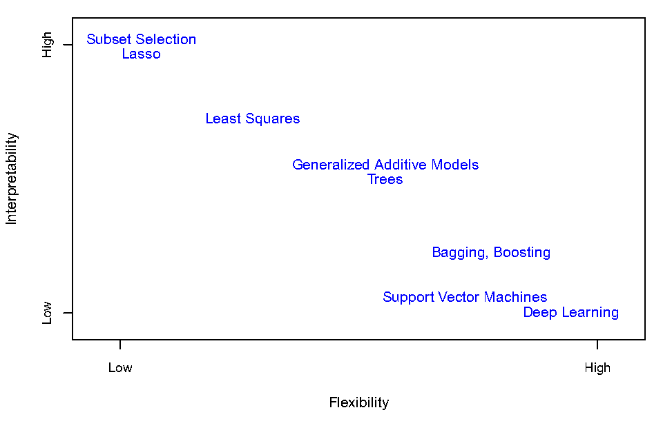

## Some preview of regression and classification as supervised learning

### Assess Model Accuracy

- Suppose we fit a model $\hat{f}(x)$ to some training data $Train = \{x_i, y_i\}^N_{i=1}$ , and we wish to see how well it performs
  - We could compute the average squared prediction error over $Train$

$$MSE_{Train} = \textrm{Average}_{i\in \textrm{ Tr }}[y_i − \hat{f}(x_i)]^2$$

- this may be biased toward more `overfit` models
- we should compute it using test data $Test = \{x_j, y_j \}^M_{j=1}$

$$MSE_{Test} = \textrm{Average}_{i \in \textrm{Test}} [y_i − \hat{f}(x_i)]^2$$

## Some preview of regression and classification as supervised learning

### Bias-Variance Trade-off

- Suppose we have fit a model $\hat{f}(x)$ to some training data $Train$
- let $(x_0, y_0)$ be a test observation drawn from the population
- If the true model is $Y = f(X) + \epsilon$, then

$$E\left (y_0 − \hat{f}(x_0) \right)^2 = Var(\hat{f}(x_0)) + [Bias(\hat{f}(x_0))]^2 + Var(\epsilon)$$

$\quad$ where $Bias(\hat{f}(x_0))=E[\hat{f}(x_0)]-f(x_0)$

## Some preview of regression and classification as supervised learning

### Classification Problems

- In classification problems, the response variable is qualitative
- a classic problem is spam email detection
  - $\mathcal{C}$= (spam, ham)
- the goal is to build a classifier that can predict the class label of a new observation
  - .i.e. $\mathcal{C}(X)$ where $X$ is the feature vector
  - the classifier is a function $\hat{f}(X)$ that maps the feature vector to the class label
- Is there an ideal $C(X)$?
- Suppose the $K$ elements in $C$ are numbered $1, 2, \cdots, K$
  - we can encode the qualitative response as a vector of $K$ binary variables
  - $Y_k = 1$ if the response is in class $k$ and $0$ otherwise
- let us rephrase the classification problem as a conditional probability problem

$$p_k(x)=Pr(Y=k|X=x), \quad k=1,2,\dots,K$$

## Some preview of regression and classification as supervised learning

### Classification Problems

- there are many different methods to estimate $\hat{C}(x)$
  - logistic regression, linear discriminant analysis, K-nearest neighbors, and support vector machines
- we measure the performance of $\hat{C}(x)$ using the misclassification error rate:

$$Err_{Test}= \textrm{Average}_{i \in Test} I[y_i \neq \hat{C}(x_i)]$$

## References

James, G., D. Witten, T. Hastie, and R. Tibshirani. 2023. *An Introduction to Statistical Learning with Applications in r*. Second edition. Springer.

Lantz, Brett. 2023. *Machine Learning with r : Learn Techniques for Building and Improving Machine Learning Models, from Data Preparation to Model Tuning, Evaluation, and Working with Big Data*. Fourth edition. Expert Insight. Birmingham, UK: Packt Publishing Limited.